# Объединение и сохранение данных

```python
from urllib.request import urlretrieve
import pandas as pd

covid_data = 'https://github.com/SerjiEvg/data-analysis/blob/main/data/COVID-19%20data%20by%20regions%20of%20RUSSIA.csv?raw=true'
urlretrieve(covid_data, 'COVID-19 data by regions of RUSSIA.csv')
covid_df = pd.read_csv('COVID-19 data by regions of RUSSIA.csv', sep=';')
```

```python
covid_df
```

|  | Регион | Федеральный округ | дата | случаи заболевания | население | количество смертей |
| --- | --- | --- | --- | --- | --- | --- |
| 0 | Республика Бурятия | Дальневосточный федеральный округ | 25.02.2020 | NaN | 986109 | NaN |
| 1 | Алтайский край | Сибирский федеральный округ | 25.02.2020 | NaN | 2317052 | NaN |
| 2 | Амурская область | Дальневосточный федеральный округ | 25.02.2020 | NaN | 790676 | NaN |
| 3 | Архангельская область | Северо-Западный федеральный округ | 25.02.2020 | NaN | 1092277 | NaN |
| 4 | Астраханская область | Южный федеральный округ | 25.02.2020 | NaN | 1005967 | NaN |
| ... | ... | ... | ... | ... | ... | ... |
| 9957 | Челябинская область | Уральский федеральный округ | 30.06.2020 | 144.0 | 3466960 | NaN |
| 9958 | Чеченская Республика | Северо-Кавказский федеральный округ | 30.06.2020 | 5.0 | 1476752 | NaN |
| 9959 | Чукотский АО | Дальневосточный федеральный округ | 30.06.2020 | NaN | 50726 | NaN |
| 9960 | Ямало-Ненецкий автономный округ | Уральский федеральный округ | 30.06.2020 | 248.0 | 544008 | NaN |
| 9961 | Ярославская область | Центральный федеральный округ | 30.06.2020 | 44.0 | 1253189 | NaN |

9962 rows × 6 columns

Чтобы определить другие показатели, такие как количество тестов на миллион, число случаев на миллион и т.д., нам требуется дополнительная информация о стране, а именно, его население. Давайте загрузим еще один файл locations.csv, содержащий информацию о здоровье для многих стран, включая Россию:

```python
urlretrieve('https://github.com/SerjiEvg/data-analysis/blob/main/data/locations.csv?raw=true', 'locations.csv')
```

```
('locations.csv', <http.client.HTTPMessage at 0x7f84159c1490>)
```

```python
locations_df = pd.read_csv('locations.csv')

locations_df
```

|  | location | continent | population | life_expectancy | hospital_beds_per_thousand | gdp_per_capita |
| --- | --- | --- | --- | --- | --- | --- |
| 0 | Afghanistan | Asia | 3.892834e+07 | 64.83 | 0.500 | 1803.987 |
| 1 | Albania | Europe | 2.877800e+06 | 78.57 | 2.890 | 11803.431 |
| 2 | Algeria | Africa | 4.385104e+07 | 76.88 | 1.900 | 13913.839 |
| 3 | Andorra | Europe | 7.726500e+04 | 83.73 | NaN | NaN |
| 4 | Angola | Africa | 3.286627e+07 | 61.15 | NaN | 5819.495 |
| ... | ... | ... | ... | ... | ... | ... |
| 207 | Yemen | Asia | 2.982597e+07 | 66.12 | 0.700 | 1479.147 |
| 208 | Zambia | Africa | 1.838396e+07 | 63.89 | 2.000 | 3689.251 |
| 209 | Zimbabwe | Africa | 1.486293e+07 | 61.49 | 1.700 | 1899.775 |
| 210 | World | NaN | 7.794799e+09 | 72.58 | 2.705 | 15469.207 |
| 211 | International | NaN | NaN | NaN | NaN | NaN |

212 rows × 6 columns

Выведем всю информацию строки, где ключ location из фрейма locations_df равен значению Russia

```python
locations_df[locations_df.location == "Russia"]
```

|  | location | continent | population | life_expectancy | hospital_beds_per_thousand | gdp_per_capita |
| --- | --- | --- | --- | --- | --- | --- |
| 157 | Russia | Europe | 145934460.0 | 72.58 | 8.05 | 24765.954 |

Мы можем объединить эти данные в наш существующий фрейм данных, добавив дополнительные столбцы. Однако, чтобы объединить два фрейма данных, нам нужен хотя бы один общий столбец. Давайте вставим столбец location в другой фрейм данных covid_df со всеми значениями, установленными для значения "Russia".

```python
covid_df['location'] = "Russia"

covid_df
```

|  | Регион | Федеральный округ | дата | случаи заболевания | население | количество смертей | location |
| --- | --- | --- | --- | --- | --- | --- | --- |
| 0 | Республика Бурятия | Дальневосточный федеральный округ | 25.02.2020 | NaN | 986109 | NaN | Russia |
| 1 | Алтайский край | Сибирский федеральный округ | 25.02.2020 | NaN | 2317052 | NaN | Russia |
| 2 | Амурская область | Дальневосточный федеральный округ | 25.02.2020 | NaN | 790676 | NaN | Russia |
| 3 | Архангельская область | Северо-Западный федеральный округ | 25.02.2020 | NaN | 1092277 | NaN | Russia |
| 4 | Астраханская область | Южный федеральный округ | 25.02.2020 | NaN | 1005967 | NaN | Russia |
| ... | ... | ... | ... | ... | ... | ... | ... |
| 9957 | Челябинская область | Уральский федеральный округ | 30.06.2020 | 144.0 | 3466960 | NaN | Russia |
| 9958 | Чеченская Республика | Северо-Кавказский федеральный округ | 30.06.2020 | 5.0 | 1476752 | NaN | Russia |
| 9959 | Чукотский АО | Дальневосточный федеральный округ | 30.06.2020 | NaN | 50726 | NaN | Russia |
| 9960 | Ямало-Ненецкий автономный округ | Уральский федеральный округ | 30.06.2020 | 248.0 | 544008 | NaN | Russia |
| 9961 | Ярославская область | Центральный федеральный округ | 30.06.2020 | 44.0 | 1253189 | NaN | Russia |

9962 rows × 7 columns

еперь мы видим, что для DataFrame covid_df был добавлен еще один столбец location.

Мы можем добавить столбцы из фрейма locations_df во фрейм covid_df с помощью метода merge().

```python
merged_df = covid_df.merge(locations_df, on="location")

merged_df
```

|  | Регион | Федеральный округ | дата | случаи заболевания | население | количество смертей | location | continent | population | life_expectancy | hospital_beds_per_thousand | gdp_per_capita |
| --- | --- | --- | --- | --- | --- | --- | --- | --- | --- | --- | --- | --- |
| 0 | Республика Бурятия | Дальневосточный федеральный округ | 25.02.2020 | NaN | 986109 | NaN | Russia | Europe | 145934460.0 | 72.58 | 8.05 | 24765.954 |
| 1 | Алтайский край | Сибирский федеральный округ | 25.02.2020 | NaN | 2317052 | NaN | Russia | Europe | 145934460.0 | 72.58 | 8.05 | 24765.954 |
| 2 | Амурская область | Дальневосточный федеральный округ | 25.02.2020 | NaN | 790676 | NaN | Russia | Europe | 145934460.0 | 72.58 | 8.05 | 24765.954 |
| 3 | Архангельская область | Северо-Западный федеральный округ | 25.02.2020 | NaN | 1092277 | NaN | Russia | Europe | 145934460.0 | 72.58 | 8.05 | 24765.954 |
| 4 | Астраханская область | Южный федеральный округ | 25.02.2020 | NaN | 1005967 | NaN | Russia | Europe | 145934460.0 | 72.58 | 8.05 | 24765.954 |
| ... | ... | ... | ... | ... | ... | ... | ... | ... | ... | ... | ... | ... |
| 9957 | Челябинская область | Уральский федеральный округ | 30.06.2020 | 144.0 | 3466960 | NaN | Russia | Europe | 145934460.0 | 72.58 | 8.05 | 24765.954 |
| 9958 | Чеченская Республика | Северо-Кавказский федеральный округ | 30.06.2020 | 5.0 | 1476752 | NaN | Russia | Europe | 145934460.0 | 72.58 | 8.05 | 24765.954 |
| 9959 | Чукотский АО | Дальневосточный федеральный округ | 30.06.2020 | NaN | 50726 | NaN | Russia | Europe | 145934460.0 | 72.58 | 8.05 | 24765.954 |
| 9960 | Ямало-Ненецкий автономный округ | Уральский федеральный округ | 30.06.2020 | 248.0 | 544008 | NaN | Russia | Europe | 145934460.0 | 72.58 | 8.05 | 24765.954 |
| 9961 | Ярославская область | Центральный федеральный округ | 30.06.2020 | 44.0 | 1253189 | NaN | Russia | Europe | 145934460.0 | 72.58 | 8.05 | 24765.954 |

9962 rows × 12 columns

Данные о местоположении для России добавляются к каждой строке в пределах covid_df. Если фрейм данных covid_df содержит данные для нескольких местоположений, то данные о местоположении соответствующей страны будут добавляться к каждой строке.

Теперь мы можем рассчитать такие показатели, как количество случаев на миллион, смертей на миллион.

```python
merged_df['cases_per_million'] = merged_df['случаи заболевания'] * 1e6 / merged_df.population

merged_df['deaths_per_million'] = merged_df['количество смертей'] * 1e6 / merged_df.population

merged_df
```

|  | Регион | Федеральный округ | дата | случаи заболевания | население | количество смертей | location | continent | population | life_expectancy | hospital_beds_per_thousand | gdp_per_capita | cases_per_million | deaths_per_million |
| --- | --- | --- | --- | --- | --- | --- | --- | --- | --- | --- | --- | --- | --- | --- |
| 0 | Республика Бурятия | Дальневосточный федеральный округ | 25.02.2020 | NaN | 986109 | NaN | Russia | Europe | 145934460.0 | 72.58 | 8.05 | 24765.954 | NaN | NaN |
| 1 | Алтайский край | Сибирский федеральный округ | 25.02.2020 | NaN | 2317052 | NaN | Russia | Europe | 145934460.0 | 72.58 | 8.05 | 24765.954 | NaN | NaN |
| 2 | Амурская область | Дальневосточный федеральный округ | 25.02.2020 | NaN | 790676 | NaN | Russia | Europe | 145934460.0 | 72.58 | 8.05 | 24765.954 | NaN | NaN |
| 3 | Архангельская область | Северо-Западный федеральный округ | 25.02.2020 | NaN | 1092277 | NaN | Russia | Europe | 145934460.0 | 72.58 | 8.05 | 24765.954 | NaN | NaN |
| 4 | Астраханская область | Южный федеральный округ | 25.02.2020 | NaN | 1005967 | NaN | Russia | Europe | 145934460.0 | 72.58 | 8.05 | 24765.954 | NaN | NaN |
| ... | ... | ... | ... | ... | ... | ... | ... | ... | ... | ... | ... | ... | ... | ... |
| 9957 | Челябинская область | Уральский федеральный округ | 30.06.2020 | 144.0 | 3466960 | NaN | Russia | Europe | 145934460.0 | 72.58 | 8.05 | 24765.954 | 0.986744 | NaN |
| 9958 | Чеченская Республика | Северо-Кавказский федеральный округ | 30.06.2020 | 5.0 | 1476752 | NaN | Russia | Europe | 145934460.0 | 72.58 | 8.05 | 24765.954 | 0.034262 | NaN |
| 9959 | Чукотский АО | Дальневосточный федеральный округ | 30.06.2020 | NaN | 50726 | NaN | Russia | Europe | 145934460.0 | 72.58 | 8.05 | 24765.954 | NaN | NaN |
| 9960 | Ямало-Ненецкий автономный округ | Уральский федеральный округ | 30.06.2020 | 248.0 | 544008 | NaN | Russia | Europe | 145934460.0 | 72.58 | 8.05 | 24765.954 | 1.699393 | NaN |
| 9961 | Ярославская область | Центральный федеральный округ | 30.06.2020 | 44.0 | 1253189 | NaN | Russia | Europe | 145934460.0 | 72.58 | 8.05 | 24765.954 | 0.301505 | NaN |

9962 rows × 14 columns

## Запись полученных данных в файлы

После завершения анализа и добавления новых столбцов мы должны записать результаты обратно в файл. В противном случае данные могут быть потеряны. Перед записью в файл давайте сначала создадим фрейм данных, содержащий только столбцы, которые мы хотим записать.

Например,

```python
result_df = merged_df[['дата',
                       'случаи заболевания',
                       'количество смертей',
                       'cases_per_million',
                       'deaths_per_million']]

result_df
```

|  | дата | случаи заболевания | количество смертей | cases_per_million | deaths_per_million |
| --- | --- | --- | --- | --- | --- |
| 0 | 25.02.2020 | NaN | NaN | NaN | NaN |
| 1 | 25.02.2020 | NaN | NaN | NaN | NaN |
| 2 | 25.02.2020 | NaN | NaN | NaN | NaN |
| 3 | 25.02.2020 | NaN | NaN | NaN | NaN |
| 4 | 25.02.2020 | NaN | NaN | NaN | NaN |
| ... | ... | ... | ... | ... | ... |
| 9957 | 30.06.2020 | 144.0 | NaN | 0.986744 | NaN |
| 9958 | 30.06.2020 | 5.0 | NaN | 0.034262 | NaN |
| 9959 | 30.06.2020 | NaN | NaN | NaN | NaN |
| 9960 | 30.06.2020 | 248.0 | NaN | 1.699393 | NaN |
| 9961 | 30.06.2020 | 44.0 | NaN | 0.301505 | NaN |

9962 rows × 5 columns

Чтобы записать данные из фрейма данных в файл, мы можем использовать, уже известную нам, функцию to_csv().

### Скачать как CSV-файл

Используйте to_csvметод DataFrame для передачи DataFrame в файл CSV. И используйте files.downloadметод для загрузки файла программно.

```python
from google.colab import files
result_df.to_csv('results.csv', index=None)
files.download('results.csv')
```

### Сохранить как файл CSV на Google Диск

Во- первых, необходимо импортировать driveи выполнить mountметод. Здесь будет монтироваться мой диск Google по этому пути /content/drive. Во- вторых, используйте openдля открытия файла, который будет параметром to_csvметода.

```python
try:
    from google.colab import drive
    drive.mount('/content/drive', force_remount=True)
    print("Google Drive mounted successfully!")
except Exception as e:
    print("Error while mounting Google Drive: {}".format(str(e)))
```

```
Google Drive mounted successfully!
```

```python
import os
DATA_PATH = '/content/drive/My Drive/Colab Notebooks/data/'

with open(os.path.join(DATA_PATH,'results.csv'), 'w', encoding = 'utf-8-sig') as f:
  result_df.to_csv(f, index=None)
```

## Базовый график с Pandas

Обычно, для построения графиков в блокноте Jupyter, используются библиотеки matplotlib или seaborn . Тем не менее, фреймы и серии данных в pandas предоставляют удобный метод plot() для быстрого и простого построения графиков.

Давайте построим линейный график, показывающий, как количество ежедневных случаев меняется с течением времени.

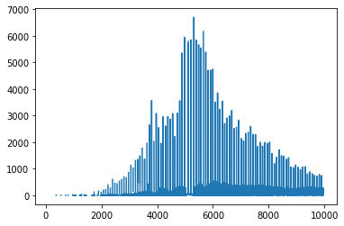

```python
result_df['случаи заболевания'].plot()
```

А теперь давайте визуализируем случаи заболевания по месяцам, используя гистограмму, чтобы визуализировать тенденцию на более высоком уровне.

```python
result_df
```

|  | дата | случаи заболевания | количество смертей | cases_per_million | deaths_per_million |
| --- | --- | --- | --- | --- | --- |
| 0 | 25.02.2020 | NaN | NaN | NaN | NaN |
| 1 | 25.02.2020 | NaN | NaN | NaN | NaN |
| 2 | 25.02.2020 | NaN | NaN | NaN | NaN |
| 3 | 25.02.2020 | NaN | NaN | NaN | NaN |
| 4 | 25.02.2020 | NaN | NaN | NaN | NaN |
| ... | ... | ... | ... | ... | ... |
| 9957 | 30.06.2020 | 144.0 | NaN | 0.986744 | NaN |
| 9958 | 30.06.2020 | 5.0 | NaN | 0.034262 | NaN |
| 9959 | 30.06.2020 | NaN | NaN | NaN | NaN |
| 9960 | 30.06.2020 | 248.0 | NaN | 1.699393 | NaN |
| 9961 | 30.06.2020 | 44.0 | NaN | 0.301505 | NaN |

9962 rows × 5 columns

```python
covid_df['Месяц'] = pd.DatetimeIndex(result_df['дата']).month
```

```python
covid_df
```

|  | Регион | Федеральный округ | дата | случаи заболевания | население | количество смертей | location | Месяц |
| --- | --- | --- | --- | --- | --- | --- | --- | --- |
| 0 | Республика Бурятия | Дальневосточный федеральный округ | 25.02.2020 | NaN | 986109 | NaN | Russia | 2 |
| 1 | Алтайский край | Сибирский федеральный округ | 25.02.2020 | NaN | 2317052 | NaN | Russia | 2 |
| 2 | Амурская область | Дальневосточный федеральный округ | 25.02.2020 | NaN | 790676 | NaN | Russia | 2 |
| 3 | Архангельская область | Северо-Западный федеральный округ | 25.02.2020 | NaN | 1092277 | NaN | Russia | 2 |
| 4 | Астраханская область | Южный федеральный округ | 25.02.2020 | NaN | 1005967 | NaN | Russia | 2 |
| ... | ... | ... | ... | ... | ... | ... | ... | ... |
| 9957 | Челябинская область | Уральский федеральный округ | 30.06.2020 | 144.0 | 3466960 | NaN | Russia | 6 |
| 9958 | Чеченская Республика | Северо-Кавказский федеральный округ | 30.06.2020 | 5.0 | 1476752 | NaN | Russia | 6 |
| 9959 | Чукотский АО | Дальневосточный федеральный округ | 30.06.2020 | NaN | 50726 | NaN | Russia | 6 |
| 9960 | Ямало-Ненецкий автономный округ | Уральский федеральный округ | 30.06.2020 | 248.0 | 544008 | NaN | Russia | 6 |
| 9961 | Ярославская область | Центральный федеральный округ | 30.06.2020 | 44.0 | 1253189 | NaN | Russia | 6 |

9962 rows × 8 columns

```python
covid_month_df = covid_df.groupby('Месяц')['случаи заболевания','население'].sum()

covid_month_df
```

| Месяц | случаи заболевания | население |
| --- | --- | --- |
| 1 | 17408.0 | 439920318 |
| 2 | 19257.0 | 586665416 |
| 3 | 22072.0 | 3226817276 |
| 4 | 110766.0 | 3080641449 |
| 5 | 193086.0 | 3228077180 |
| 6 | 156800.0 | 3228077180 |
| 7 | 21373.0 | 586665416 |
| 8 | 20862.0 | 586665416 |
| 9 | 20888.0 | 586665416 |
| 10 | 21205.0 | 586665416 |
| 11 | 22110.0 | 586665416 |
| 12 | 22078.0 | 586665416 |

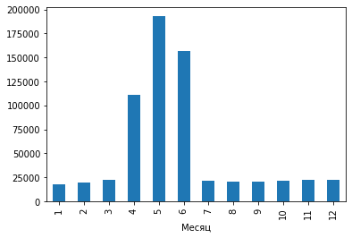

```python
covid_month_df['случаи заболевания'].plot(kind='bar')
```

```python
covid_month_df2 = covid_df.groupby('Месяц')['случаи заболевания'].sum()

covid_month_df2
```

```
Месяц
1      17408.0
2      19257.0
3      22072.0
4     110766.0
5     193086.0
6     156800.0
7      21373.0
8      20862.0
9      20888.0
10     21205.0
11     22110.0
12     22078.0
Name: случаи заболевания, dtype: float64
```

```python
covid_month_df2['случаи заболевания'].plot(kind='bar')
```

[output not shown]